# Assignment 1

Morris Chi

2025-09-24

13/15

I did 14/15 questions

# 1

In class quizzes are 10%, Labs are also 10%, Chapter quizzes are 5%, Project 1 is 3.33%, Project 2 is 6.67%, the Midterm is 20%, Assignments are 15%,

The Final Exam is 30%.

An A in the class is 90 or above

A’s are 90 and above, B’s are 80 and above, C’s are 60s and 70s, D’s are 50 and above and F’s are anything less than 50. There’s no curves

# 2

1. Coplot is below
2. It shows the characteristics of Catfish within the RIVERs FCM, LCM, and SCM
3. Marks each unique mile locations there is
4. Counts how many unique mile locations there are, which is 17
5. There’s no fish that match those combinations of RIVER and SPECIES
6. 45

```r
ddt = read.csv("DDT-1.csv")
head(ddt)
```

```
##   RIVER MILE  SPECIES LENGTH WEIGHT DDT
## 1   FCM    5 CCATFISH   42.5    732  10
## 2   FCM    5 CCATFISH   44.0    795  16
## 3   FCM    5 CCATFISH   41.5    547  23
## 4   FCM    5 CCATFISH   39.0    465  21
## 5   FCM    5 CCATFISH   50.5   1252  50
## 6   FCM    5 CCATFISH   52.0   1255 150
```

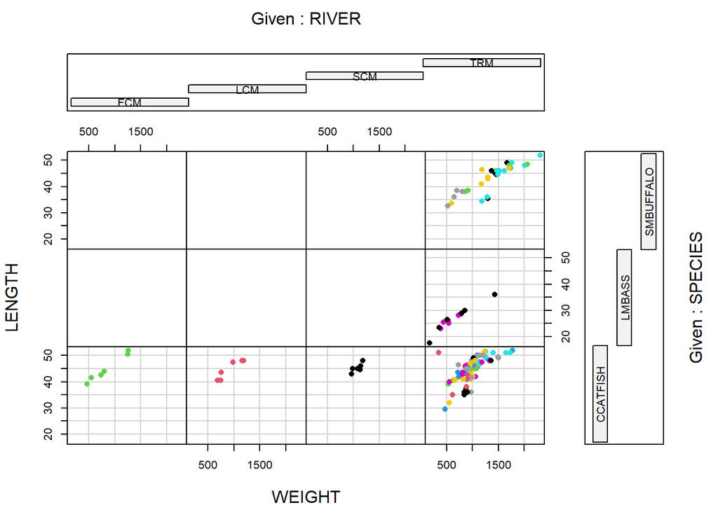

```r
ddt$MILE <- as.factor(ddt$MILE)

coplot(LENGTH ~ WEIGHT | RIVER * SPECIES, data = ddt, col = ddt$MILE, pch = 16)
```

```r
subset_data <- subset(ddt, SPECIES == "CCATFISH" & RIVER == "FCM")

mean_DDT <- mean(subset_data$DDT)

mean_DDT
```

```
## [1] 45
```

```r
m=with(ddt, as.numeric(factor(MILE)))
length(unique(m))
```

```
## [1] 17
```

# 3

1. Quantitative
2. Quantitative
3. Qualitative
4. Quantitative
5. Qualitative
6. Quantitative
7. Qualitative

# 4

1. Simple Random Sampling, Stratified Random Sampling, Cluster Sampling, Systematic Sampling
2. Simple Random Sampling: The simple way of sampling, where everything has an equal chance to be selected, making it truly random

Stratified Sampling: The population gets split up into smaller groups called strata where the groups are made up of people or things that share common characteristics, and then those smaller groups are each randomly sampled

Cluster Sampling: When the population is too large, sometimes smaller chunks, or “clusters” of the total population is chosen and then either all or only some of the cluster is sampled from

Systematic Sampling: Out of the total population, only one every kth object or person is chosen as a sample

# 5

1. 2. 56.45357

```r
mtbe = read.csv("MTBE.csv")

head(mtbe)
```

```
##     pH SpConduct DissOxy RoadsPct IndPct UrbanPct DevPct WellClass Aquifier
## 1 7.87     290.0    0.58     1.34      0    17.77  17.77   Private  Bedrock
## 2 8.63     225.9    0.84     0.72      0    10.43  10.43   Private  Bedrock
## 3 7.11     157.4    8.37     1.92      0    29.62  50.01   Private  Bedrock
## 4 7.98     723.6    0.41     2.76      0    41.65  41.65   Private  Bedrock
## 5 7.88     148.7    1.44     3.51      0    51.21  51.21   Private  Bedrock
## 6 8.36     198.2    0.18     1.48      0    22.49  29.19   Private  Bedrock
##     Depth SafeYld Distance MTBE.Detect MTBE.Level HouseDen PopDen
## 1  60.960      NA  2386.29 Below Limit        0.2   131.16  43.19
## 2  36.576      NA  3667.69 Below Limit        0.2    47.69  24.52
## 3 152.400      NA  2324.15 Below Limit        0.2    85.16  33.32
## 4      NA      NA   788.88 Below Limit        0.2   134.77  46.61
## 5  91.440      NA  1337.88 Below Limit        0.2   198.54  78.58
## 6 115.824      NA  2396.74 Below Limit        0.2   206.73  59.47
```

```r
dim(mtbe)
```

```
## [1] 223  16
```

```r
ind=sample(1:223,5,replace=FALSE)
mtbe[ind,]
```

```
##       pH SpConduct DissOxy RoadsPct IndPct UrbanPct DevPct WellClass Aquifier
## 194 8.12     161.2    0.49     1.77  11.35    32.64  32.64    Public  Bedrock
## 135 7.22     286.5    0.60     3.28   0.00    40.78  40.78    Public  Bedrock
## 9   7.55    1077.0    3.93     1.50   0.00    16.79  16.79   Private  Bedrock
## 187 8.81     241.4    0.36     4.72   0.00    50.40  55.44    Public  Bedrock
## 120 7.66     293.7    0.79     3.55   3.20    36.81  36.81    Public  Bedrock
##       Depth   SafeYld Distance MTBE.Detect MTBE.Level HouseDen PopDen
## 194 152.400  18.92506   270.91 Below Limit       0.20    39.59  14.79
## 135  45.720 113.55034   367.52 Below Limit       0.20   117.22   0.00
## 9        NA        NA  1672.33      Detect       1.32    86.89  26.61
## 187  70.104  26.49508  1272.95 Below Limit       0.20   471.21 178.30
## 120  91.440 227.10068  1346.78 Below Limit       0.20   479.30 282.69
```

```r
mtbeo=na.omit(mtbe)

depth=mtbeo[mtbeo$Aquifier=="Bedrock",]$Depth

sd(depth)
```

```
## [1] 56.45357
```

```r
mtbe = read.csv("MTBE.csv")

mtbe$Public/ mtbe$BedRock
```

```
## numeric(0)
```

# 6

1. 1. eq plot is below
   2. 2

```r
eq = read.csv("earthquake.csv")

ind=sample(1:2929,30,replace=FALSE)
mtbe[ind,]
```

[output not shown]

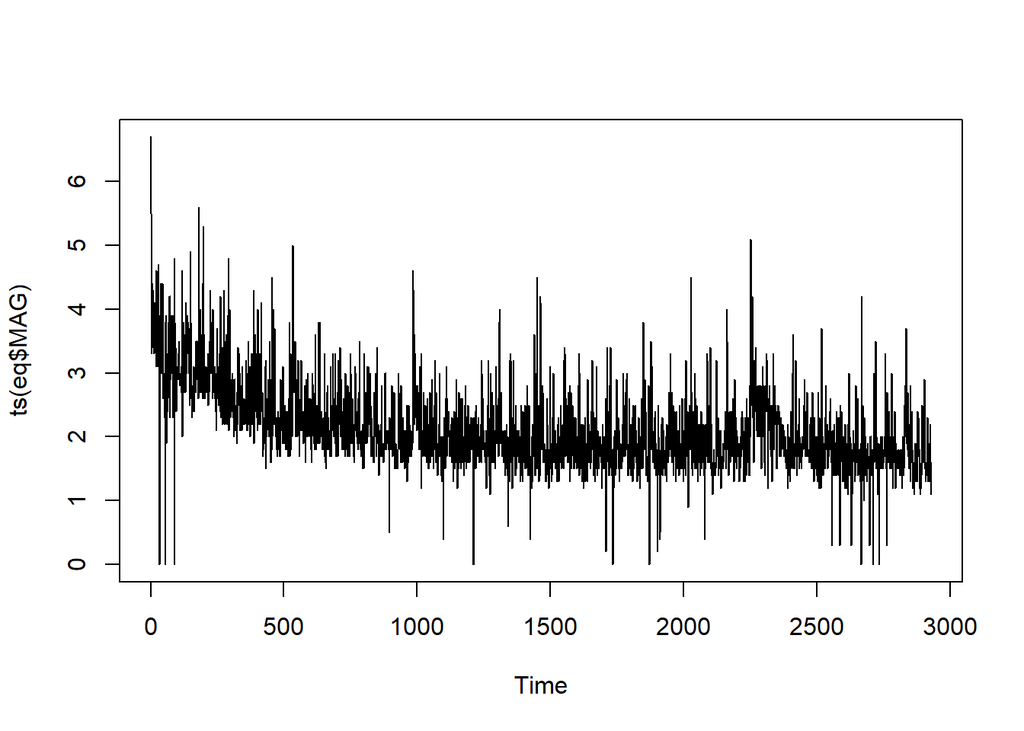

```r
plot(ts(eq$MAG))
```

```r
median_value <- median(eq$MAG)

median_value
```

```
## [1] 2
```

# 7

1. Designed Experiment with Stratified Sample
2. All the fish in the Tennessee River and its tributaries(Flint Creek, Limestone Creek, Spring Creek)
3. Capture Location, Species of Fish

# 8

1. Bar graph
2. Type of Robotic Limbs
3. Legs Only
4. Legs Only: 0.594

Wheels Only: 0.189

Both: 0.075

None: 0.142

5. Pareto diagram below

```r
legs_only <- 63
wheels_only <- 20
both <- 8
none <- 15
total <- 106

rel_legs_only <- legs_only / total
rel_wheels_only <- wheels_only / total
rel_both <- both / total
rel_none <- none / total

cat("Relative Frequency of Legs Only:", rel_legs_only, "\n")
```

```
## Relative Frequency of Legs Only: 0.5943396
```

```r
cat("Relative Frequency of Wheels Only:", rel_wheels_only, "\n")
```

```
## Relative Frequency of Wheels Only: 0.1886792
```

```r
cat("Relative Frequency of Both Legs & Wheels:", rel_both, "\n")
```

```
## Relative Frequency of Both Legs & Wheels: 0.0754717
```

```r
cat("Relative Frequency of Neither:", rel_none, "\n")
```

```
## Relative Frequency of Neither: 0.1415094
```

```r
library(qcc)
```

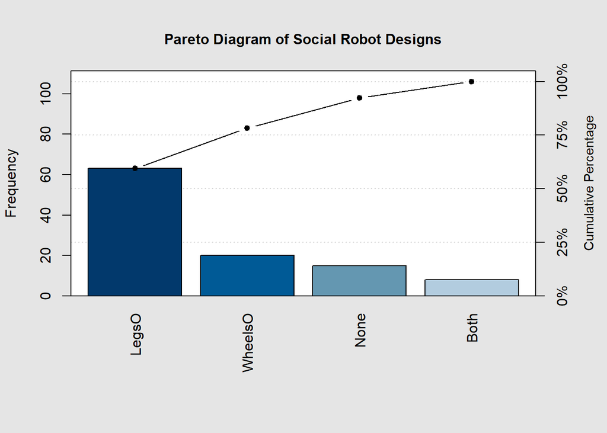

```
##
## Pareto chart analysis for freq
##           Frequency Cum.Freq. Percentage Cum.Percent.
##   LegsO    63.00000  63.00000   59.43396     59.43396
##   WheelsO  20.00000  83.00000   18.86792     78.30189
##   None     15.00000  98.00000   14.15094     92.45283
##   Both      8.00000 106.00000    7.54717    100.00000
```

```r
freq <- c(15, 8, 63, 20)
names(freq) <- c("None", "Both", "LegsO", "WheelsO")
pareto.chart(freq, main = "Pareto Diagram of Social Robot Designs")
```

# 9

1. Explorer
2. Remote Code Execution

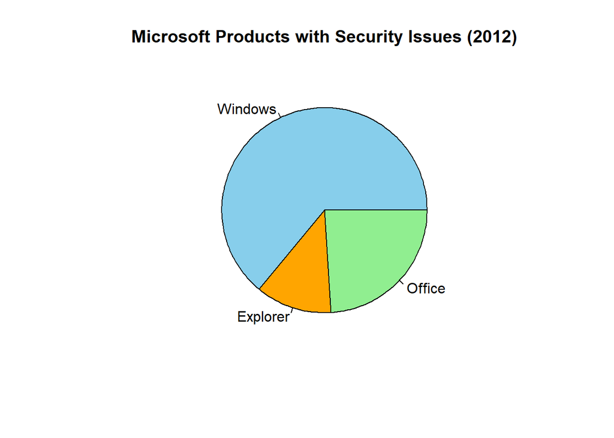

```r
library(ggplot2)
products <- c("Windows", "Explorer", "Office")
issues <- c(32, 6, 12)

names(issues) <- products

pie(issues, main = "Microsoft Products with Security Issues (2012)", col = c("skyblue", "orange", "lightgreen"))
```

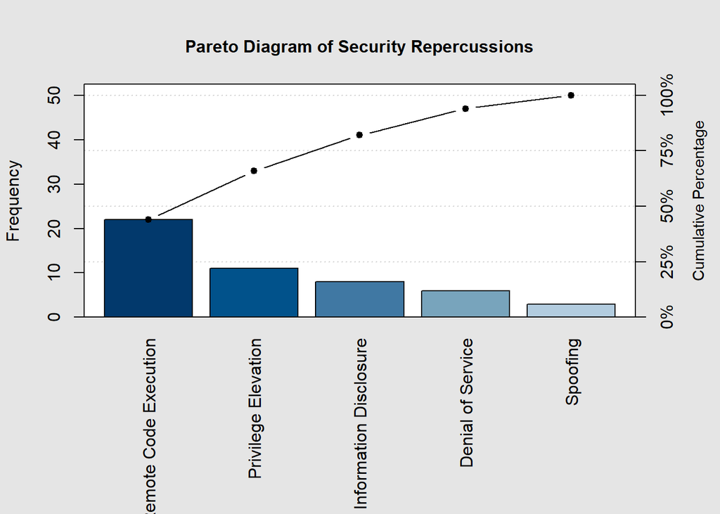

```
##
## Pareto chart analysis for repercussions
##                          Frequency Cum.Freq. Percentage Cum.Percent.
##   Remote Code Execution         22        22         44           44
##   Privilege Elevation           11        33         22           66
##   Information Disclosure         8        41         16           82
##   Denial of Service              6        47         12           94
##   Spoofing                       3        50          6          100
```

```r
library(qcc)

repercussions <- c(6, 8, 22, 3, 11)
names(repercussions) <- c("Denial of Service", "Information Disclosure", "Remote Code Execution", "Spoofing", "Privilege Elevation")

pareto.chart(repercussions, main = "Pareto Diagram of Security Repercussions")
```

# 10

10% of the modules had defective code

```r
swd = read.csv("SWDEFECTS.csv")

library(plotrix)
tab=table(swd$defect)
rtab=tab/sum(tab)
round(rtab,2)
```

```
##
## FALSE  TRUE
##   0.9   0.1
```

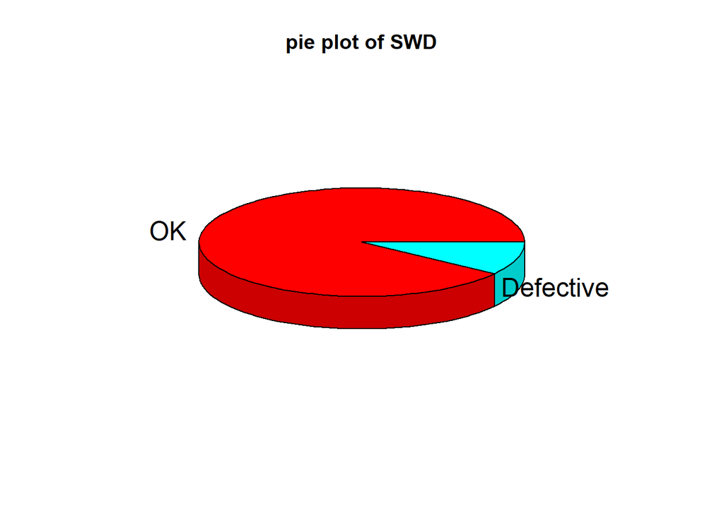

```r
pie3D(rtab,labels=list("OK","Defective"),main="pie plot of SWD")
```

# 11

# 12

(0.784, 2.978) micrometers

```r
roughness <- c(1.72, 2.5, 2.16, 2.13, 1.06, 2.24, 2.31, 2.03, 1.09, 1.4, 2.57, 2.64, 1.26, 2.05, 1.19, 2.13, 1.27, 1.51, 2.41, 1.95)

mean_rough <- mean(roughness)
sd_rough <- sd(roughness)
n <- length(roughness)

t_value <- qt(0.975, df = n - 1)

lower_bound <- mean_rough - t_value * sd_rough
upper_bound <- mean_rough + t_value * sd_rough

cat("95% Prediction Interval: [", lower_bound, ",", upper_bound, "]\n")
```

```
## 95% Prediction Interval: [ 0.7844408 , 2.977559 ]
```

# 13

1. Mean: 12.82, Median: 5, Mode: 4

On average they’re finding 12.82 ant species at each site. The most common number of species they find at a site is 4.

The middle number of the data of ant species discovered is 5

2. I would say the median, as the mean is really skewed by some crazy outliers of 49 and 52, and mode might not represent all the locations properly
3. Mean: 40.4, Median: 40, Mode: 40
4. Mean: 128, Median: 26, Mode: 30
5. YES

I don’t believe it was necessary to show the work for this question, the majority of it was just counting.

Finding the mean was pretty much just adding it all up and then dividing by the total count, R really wasn’t needed to do something like that.

# 14

1. Created a histogram
2. Yes, there is evidence of Galaxy Cluster A1775 being a double cluster, as the histogram has 2 distinct peaks, instead of only one, showing that there is indeed 2 different clusters of velocities, or 2 groups of galaxies moving at different velocities.
3. I made the numerical measures below
4. If there is a galaxy velocity of 20,000 km/s, this galaxy is likely to belong to cluster A1775A, as the minimum velocity of A1775B is 21,911, which is greater than 20,000, while the maximum of A1775A is 20,785, which is higher than 20,000. As such, it fits in much better in A1775A than A1775B.

```r
galaxy = read.csv("GALAXY2.csv")

# Read the CSV (no header)
gal_data <- read.csv("GALAXY2.csv", header = FALSE)

# Flatten into a vector, then convert to numeric
galaxy <- as.numeric(unlist(gal_data))
# Remove any NA (just in case)
galaxy <- galaxy[!is.na(galaxy)]

# Check
is.numeric(galaxy)   # should be TRUE
```

```
## [1] TRUE
```

```r
length(galaxy)       # should be the number of galaxy velocities
```

```
## [1] 51
```

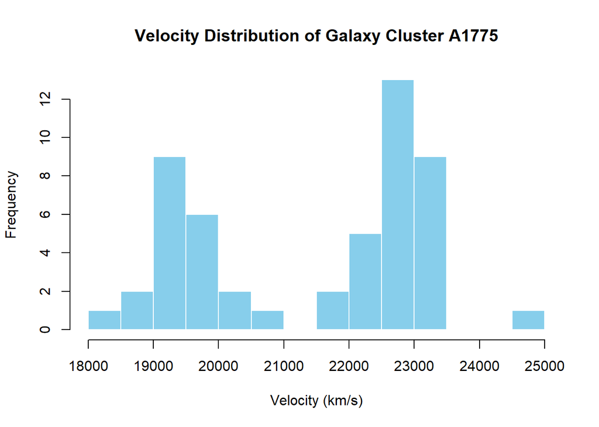

```r
hist(galaxy,
     breaks = 10,
     col = "skyblue",
     border = "white",
     main = "Velocity Distribution of Galaxy Cluster A1775",
     xlab = "Velocity (km/s)")
```

```r
# Split into two groups
A1775A <- galaxy[galaxy < 21000]
A1775B <- galaxy[galaxy >= 21000]

# Descriptive stats for each group
summary(A1775A)
```

```
##    Min. 1st Qu.  Median    Mean 3rd Qu.    Max.
##   18499   19111   19408   19462   19740   20785
```

```r
cat("Mean A1775A =", mean(A1775A), " SD =", sd(A1775A), "\n")
```

```
## Mean A1775A = 19462.24  SD = 532.2868
```

```r
summary(A1775B)
```

```
##    Min. 1st Qu.  Median    Mean 3rd Qu.    Max.
##   21911   22541   22780   22838   23106   24909
```

```r
cat("Mean A1775B =", mean(A1775B), " SD =", sd(A1775B), "\n")
```

```
## Mean A1775B = 22838.47  SD = 560.9767
```

# 15

[figure not shown]

```r
library(ggplot2)
ggplot(ddt, aes(x = RIVER, y = LENGTH, fill = SPECIES)) +
  geom_boxplot() +
  ggtitle("Morris Chi") +
  xlab("Species") +
  ylab("Weight") +
  theme_minimal()
```